# Statistical Inference & Measures of Effect: Workshop

Adam La Caze School of Pharmacy The University of Queensland

May 2025

**Objectives**

1. Understand the logic of statistical testing in clinical trials
2. Demonstrate an understanding of key statistical concepts: hypothesis testing, $p$ values, confidence intervals and power
3. Be able to describe and interpret common measures of effect used in clinical epidemiology
4. Be able to critically appraise a clinical trial

We will practice applying these concepts using these three papers:

- Zinman et al. (2015) [*Empagliflozin, Cardiovascular Outcomes, and Mortality in Type 2 Diabetes*](https://www.nejm.org/doi/10.1056/NEJMoa1504720)
- SEARCH Collaborative Group (2010) *Intensive lowering of LDL cholesterol with 80 mg versus 20 mg simvastatin daily in 12 064 survivors of myocardial infarction: a double-blind randomised trial*
- Rosenstock et al. (2018) [*Effect of ertugliflozin on glucose control, body weight, blood pressure and bone density in type 2 diabetes mellitus inadequately controlled on metformin monotherapy (VERTIS MET)*](https://dom-pubs.onlinelibrary.wiley.com/doi/abs/10.1111/dom.13103)

**Task**

1. Determine the PICO for the study
2. Appraise the study methods
3. Interpret the results of the study
4. Consider external validity

## A structured approach to critical appraisal

[interactive chart not shown]

# Zinman 2015

## PICO

| Participants | Type 2 diabetes with established cardiovascular disease |
| --- | --- |
| Intervention | Empagliflozin 10mg or 25mg daily (median duration 3 years) |
| Comparator | Placebo |
| Outcome | Composite of death from cardiovascular causes, nonfatal myocardial infarction, or nonfatal stroke |

## Appraise methods

- Discuss *inferiority* c.f. *superiority* trials
- Randomized
- Similar groups at baseline; participants accounted for

## Non-inferiority trials

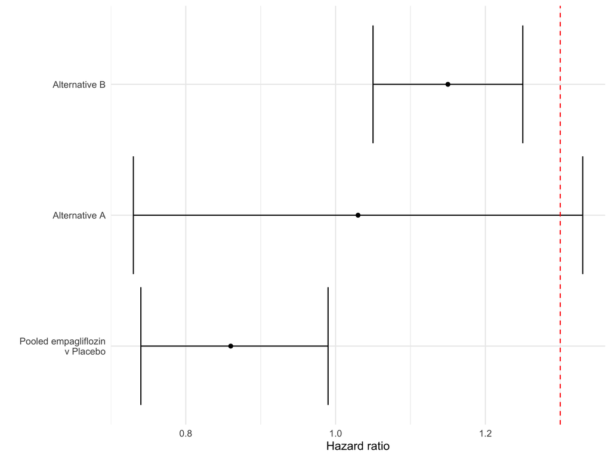

## Interpret results

> Results for primary outcome: empaglifloxin 10.5%; placebo 12.1%; HR 0.86, CI 95% 0.74 to 0.99; p = 0.04 for superiority.

ARR = 12.1 - 10.5 = 1.6%

NNT = 100/1.6 = 62.5

You need to treat 62.5 patients with type 2 diabetes and established cardiovascular disease with empagliflozin for 3 years rather than placebo to prevent one patient from the composite endpoint (death from cardiovascular causes, nontatal MI, nonfatal stroke).

## Applicability

This is an unexpected result and emphasises the importance of this class of drugs for management of T2DM

# SEARCH

SEARCH Collaborative Group. (2010). Intensive lowering of LDL cholesterol with 80 mg versus 20 mg simvastatin daily in 12 064 survivors of myocardial infarction: A double-blind randomised trial. *The Lancet*, 376(10), 1658–1669. doi:10.1016/S0140-6736(13)61970-4

## PICO

| Participants | History of myocardial infarction; modest total cholesterol levels (more than 3.5 mmol/L if on statin; 4.5 mmol/L if no statin) |
| --- | --- |
| Intervention | Simvastatin 80mg |
| Comparator | Simvastatin 20mg |
| Outcome | Major vascular event (changed from major coronary event) |

## Interpret results

> S80 24.5% cf S20 25.7%, Risk Ratio 0.94 (0.88–1.01), p=0.1
- Average LDL reduction 0.35mmol/L
- More myopathy

## Appraise methods

- Did not achieve the expected LDL reduction (0.35 c.f. 0.5 mmol/L)
- Intention-to-treat analysis

## Differential drop-out/drop-in

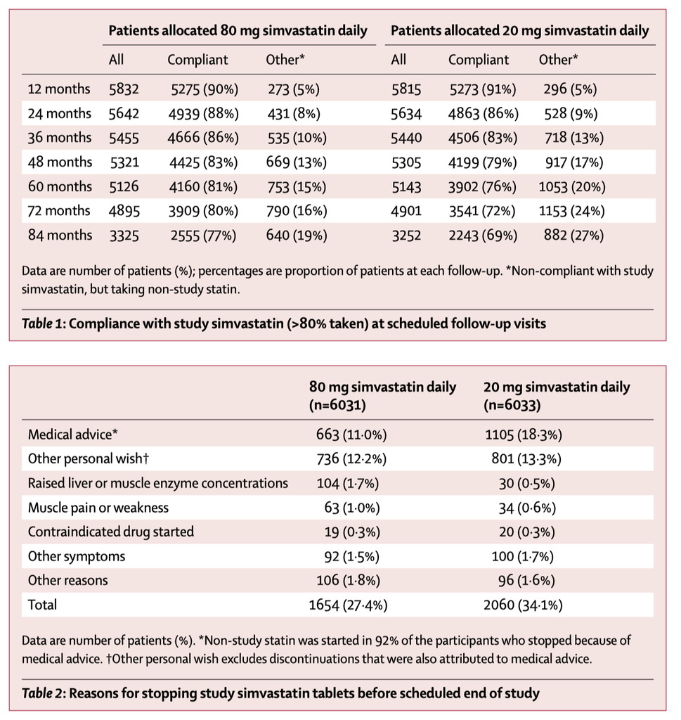

## Applicability

- Consider safety (increased risk of myopathy, rhadomyolysis)
- What does this say for cholesterol lowering?

# Intention-to-treat

## Case study

Imagine the following scenario:[^1]

- A treatment produces a *true* 20% relative risk reduction on the primary endpoint
- The untreated baseline risk in the population is 10%
- A trial is conducted with 1000 participants receiving treatment and 1000 participants receiving control
- 20% of each trial group does not comply with the allocated treatment
  - 200 of the 1000 participants **drop out** of the **treatment** group
  - 200 of the 1000 participants of the **control** group **drop in** to non-study drug *treatment*

The results of the study under different types of analysis are provided in the table.

RR for each type of analysis.`Full compliance’ refers to the result if there was no drop-outs/drop-ins.

| Type of analysis | Relative risk |
| --- | --- |
| Intention-to-treat analysis | 0.91 |
| Per protocol analysis | 1.07 |
| Treatment-received analysis | 1.20 |
| Full compliance | 0.80 |

Explain the very different results observed on the different analysis types. ([Table](https://docs.google.com/spreadsheets/d/1wGTJib51T5mHlf-Gx5Mv3JsUDIhzOLDC9PmfQ_3exT8/edit?usp=sharing))

Will the result for `Full compliance’ differ for different analysis types?

# Rosenstock

Rosenstock, J., Frias, J., Páll, D., Charbonnel, B., Pascu, R., Saur, D., … Terra, S. G. (2018). Effect of ertugliflozin on glucose control, body weight, blood pressure and bone density in type 2 diabetes mellitus inadequately controlled on metformin monotherapy (VERTIS MET). Diabetes, Obesity and Metabolism, 20(3), 520–529. https://doi.org/10.1111/dom.13103

## PICO

| Participants | T2DM with inadequately controlled HbA1c with metformin monotherapy (>1500mg/d); stratified according to sex and menopausal status |
| --- | --- |
| Intervention | ertugliflozin 5mg or 15mg daily |
| Comparator | placebo |
| Outcome | 1EP: change from baseline in HbA1c at W26 (study continued for W104; this paper only reports to W26); 2EP focused on other measures of glycaemic control. |

## Appraise methods

### Was the assignment randomized?

Yes

### Were the groups similar at the start of the trial?

Yes. Nb. pre-trial screening phase to switch to metformin monotherapy and to check for adherence.

### Aside from the allocated treatment, were groups treated equally?

Yes.

### Were all patients who entered the trial accounted for? And were they analysed in the groups to which they were randomized?

Glycaemic rescue and the results from these patients were censored—this occurred in a larger proportion of subjects in the placebo arm (17.7% cf ~ 3%).

This approach was also used for the safety endpoints (other than serious AEs)—it is not clear to me why this would be the best way to go, however, given this occurred for few in the treatment group it might not have an important effect on results.

### Were measures objective or were the patients and clinicians kept “blind” to which treatment was being received?

Yes. Yes.

## Interpret the results

Difference in least squares means compared to baseline:

E5 -0.7 ($p < 0.001$)  
E15 -0.9 ($p < 0.001$)

Similar results with secondary efficacy endpoints; of note: reduction in body weight and systolic/diastolic blood pressure.

Key safety outcomes:

- Increase in rates of genital mycotic infections in women and men
- Increase in symptomatic hypoglycaemia
- No effect seen on bone mineral density

## Applicabiliuty

Need to consider:

- Pre-screening phase and how this influences patients in the trial
- Censoring data for those that needed glycaemic rescue
- Longer-term safety data (W104 results)
- Long-term clinical outcome data is important
- Where does this fit in the range of treatment options available for T2DM?

## References

Heritier, S. R., Gebski, V. J., & Keech, A. C. (2003). Inclusion of patients in clinical trial analysis: the intention-to-treat principle. *Med J Aust*, *179*(8), 438–440.

Rosenstock, J., Frias, J., Páll, D., Charbonnel, B., Pascu, R., Saur, D., Darekar, A., Huyck, S., Shi, H., Lauring, B., & Terra, S. G. (2018). Effect of ertugliflozin on glucose control, body weight, blood pressure and bone density in type 2 diabetes mellitus inadequately controlled on metformin monotherapy (VERTIS MET). *Diabetes, Obesity and Metabolism*, *20*(3), 520–529. https://doi.org/10.1111/dom.13103

SEARCH Collaborative Group. (2010). Intensive lowering of LDL cholesterol with 80 mg versus 20 mg simvastatin daily in 12 064 survivors of myocardial infarction: A double-blind randomised trial. *The Lancet*, *376*(10), 1658–1669. https://doi.org/10.1016/S0140-6736(13)61970-4

Zinman, B., Wanner, C., Lachin, J. M., Fitchett, D., Bluhmki, E., Hantel, S., Mattheus, M., Devins, T., Johansen, O. E., Woerle, H. J., Broedl, U. C., & Inzucchi, S. E. (2015). Empagliflozin, Cardiovascular Outcomes, and Mortality in Type 2 Diabetes. *New England Journal of Medicine*, *373*(22), 2117–2128. https://doi.org/10.1056/NEJMoa1504720

[^1]: The example comes from Heritier et al. (2003)